# How to identify the correct way of doing barbell lifts

Simone Kraemer

16 Februar 2018

# Introduction

Using devices such as Jawbone Up, Nike FuelBand, and Fitbit it is now possible to collect a large amount of data about personal activity relatively inexpensively. These type of devices are part of the quantified self movement - a group of enthusiasts who take measurements about themselves regularly to improve their health, to find patterns in their behavior, or because they are tech geeks. One thing that people regularly do is quantify how much of a particular activity they do, but they rarely quantify how well they do it.

# Used Data

The data can be obtained on the webpage http://groupware.les.inf.puc-rio.br/har. For more information about the data itself, please refer to “Velloso, E.; Bulling, A.; Gellersen, H.; Ugulino, W.; Fuks, H. Qualitative Activity Recognition of Weight Lifting Exercises. Proceedings of 4th International Conference in Cooperation with SIGCHI (Augmented Human ’13). Stuttgart, Germany: ACM SIGCHI, 2013”.

```r
trainData <- read.csv('https://d396qusza40orc.cloudfront.net/predmachlearn/pml-training.csv')
validationData <- read.csv('https://d396qusza40orc.cloudfront.net/predmachlearn/pml-testing.csv')
```

The target of this project is to determine whether 6 different people did barbell lifts in a correct way. The correctness can be seen in the “Classe” variable. The meaning of this variable is as follows:

- A: according to the specification
- B: throwing the elbows to the front
- C: lifting the dumbbell only halfway
- D: lowering the dumbbell only halfway
- E: throwing the hips to the front

# Prepare data for model fitting

As there are 160 predictors, they will be reduced in order to get a simpler model with a better fit. Besides raw values for each accelerometer, there are statistical values such as “skewness”, “min”, “max”, etc. These will be taken out. Also, the user name, time stamps and windows are taken out.

```r
unneededVar <- c("skewness", "min", "max", "amplitude", "avg", "stddev", "var",
                 "kurtosis", "user_name", "timestamp", "window", "X")
maskSubset <- !grepl(paste(unneededVar, collapse = "|"),
                     colnames(trainData))
trainData <- trainData[, maskSubset]
validationData <- validationData[, maskSubset]
```

In the next step, the training set will be divided in a test and a train set:

```r
set.seed(2602)
inTrain <- createDataPartition(y = trainData$classe, p = 0.7, list = FALSE)
training <- trainData[inTrain, ]
testing <- trainData[-inTrain, ]
```

# Model fitting

For model fit, the random forest method will be used. In order to make it faster, parallel computing will be used and 5-fold cross validation resampling method:

```r
# Configure parallel processing
cluster <- makeCluster(detectCores() - 1) # convention to leave 1 core for OS
registerDoParallel(cluster)

# Configure trainControl object
fitControl <- trainControl(method = "cv",
                           number = 5,
                           allowParallel = TRUE)

# Fit model
modFit <- train(classe ~ ., data = training, method = 'rf', trControl = fitControl)

# De-register parallel processing cluster
stopCluster(cluster)
registerDoSEQ()
```

# Check model fit with test data

In order to check the model quality, it will be applied to the test dataset:

```r
predTest <- predict(modFit, testing)
confMat <- confusionMatrix(predTest, testing$classe)
confMat
```

```
## Confusion Matrix and Statistics
##
##           Reference
## Prediction    A    B    C    D    E
##          A 1672    9    0    0    0
##          B    2 1128    6    0    0
##          C    0    2 1017   18    1
##          D    0    0    3  946    4
##          E    0    0    0    0 1077
##
## Overall Statistics
##
##                Accuracy : 0.9924
##                  95% CI : (0.9898, 0.9944)
##     No Information Rate : 0.2845
##     P-Value [Acc > NIR] : < 2.2e-16
##
##                   Kappa : 0.9903
##  Mcnemar's Test P-Value : NA
##
## Statistics by Class:
##
##                      Class: A Class: B Class: C Class: D Class: E
## Sensitivity            0.9988   0.9903   0.9912   0.9813   0.9954
## Specificity            0.9979   0.9983   0.9957   0.9986   1.0000
## Pos Pred Value         0.9946   0.9930   0.9798   0.9927   1.0000
## Neg Pred Value         0.9995   0.9977   0.9981   0.9964   0.9990
## Prevalence             0.2845   0.1935   0.1743   0.1638   0.1839
## Detection Rate         0.2841   0.1917   0.1728   0.1607   0.1830
## Detection Prevalence   0.2856   0.1930   0.1764   0.1619   0.1830
## Balanced Accuracy      0.9983   0.9943   0.9935   0.9900   0.9977
```

The prediction result looks very good with a model accuracy of 99.24%. It is also interesting to know the 20 most important parameters:

```r
varImp <- varImp(modFit)
varImp
```

```
## rf variable importance
##
##   only 20 most important variables shown (out of 52)
##
##                      Overall
## roll_belt             100.00
## yaw_belt               85.66
## magnet_dumbbell_z      74.57
## pitch_belt             66.08
## magnet_dumbbell_y      65.99
## pitch_forearm          60.08
## roll_forearm           56.85
## magnet_dumbbell_x      54.86
## accel_dumbbell_y       47.77
## magnet_belt_y          45.37
## magnet_belt_z          44.84
## roll_dumbbell          44.42
## accel_belt_z           44.15
## accel_dumbbell_z       39.11
## accel_forearm_x        37.54
## roll_arm               36.04
## magnet_arm_x           31.85
## yaw_dumbbell           31.13
## gyros_belt_z           30.59
## total_accel_dumbbell   28.83
```

The distinction of the classes are shown in a plot with the two most important predictors:

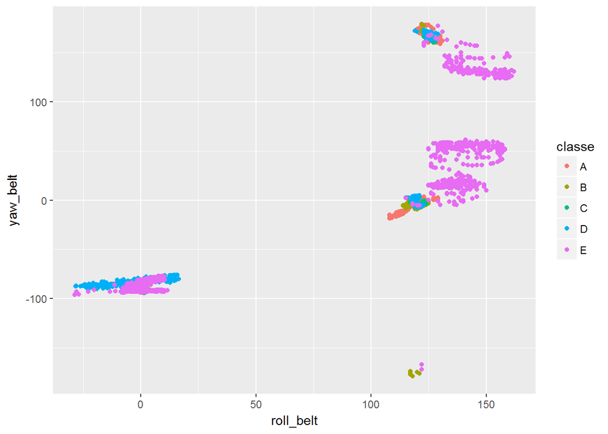

```r
g <- ggplot(data = testing, aes(roll_belt, yaw_belt, color = classe))
g <- g + geom_point() + xlab("roll_belt") + ylab("yaw_belt")
g
```

It can be seen that it is not possible to distinguish the classes just with these two predictors, however, some definite clusters can be seen.

# Prediction on validation set

As this model looks good, the prediction on the validation set can be made:

```r
predVal <- predict(modFit, newdata = validationData)
predVal
```

```
##  [1] B A B A A E D B A A B C B A E E A B B B
## Levels: A B C D E
```